# Week 9 - Homework

Author

Cameron Nemeth

### Instructions

1. Make a plot where at least one axis is a **factor in a meaningful order**.
2. You may need to use string-cleaning skills (check out the **{janitor}** [package](https://sfirke.github.io/janitor/articles/janitor.html)) to tidy column names
3. If you visualize by **tide height**, it must go Low → Mid → High on the plot

**1. Load my libraries**

```r
# Libraries
library(tidyverse)
library(readxl)
library(writexl)
library(here)
library(patchwork)
library(cowplot)
library(ggExtra)
library(kableExtra)
library(knitr)
library(janitor)
```

**2. Load in the raw data**

```r
# Load raw data
Data_Intertidal <- read_csv(here("Week_09", "Data", "intertidaldata.csv"))
```

**3. Try out the janitor package to clean data**

```r
Data_Intertidal |>
  clean_names()
```

```
# A tibble: 450 × 13
   site    transect quadrat bare_rock algae mussels small_barnacles
   <chr>      <dbl> <chr>       <dbl> <dbl>   <dbl>           <dbl>
 1 Scripps        1 Low  .         25    75       0               2
 2 Scripps        1 Mid            50     0       5              50
 3 Scripps        1 High           20    50       1              50
 4 Scripps        2 Low            10    85       0               0
 5 Scripps        2 Mid            40     5      10              40
 6 Scripps        2 High           40     5       0              55
 7 Scripps        3 Low             0   100       0               0
 8 Scripps        3 Mid            30     5      10              40
 9 Scripps        3 High           60     4       1              20
10 Scripps        4 Low             0   100       0               0
# ℹ 440 more rows
# ℹ 6 more variables: large_barnacles <dbl>, gooseneck_barnacles <dbl>,
#   anemone <dbl>, whelks_counts <dbl>, crabs_counts <dbl>, stars_counts <dbl>
```

**4. Make sure all “Quadrat” values are either Low, Mid, or High**

The data dictionary says we expect either Low, Mid, or High values, but I noticed a value of Mid 1, so I want to see what values exist and to fix any errors.

```r
# Check the values in Quadrat
unique(Data_Intertidal$Quadrat)
```

```
[1] "Low  ." "Mid"    "High"   "Low"    "Mid  1"
```

```r
# There is "Low  ." and "Mid 1"
```

```r
# Write code to fix those two cases

# Learning how to use substitute function, maybe there is a better way, but this is what I found that may work for now.
Data_Intertidal$Quadrat <- sub("^\\s*(Low|Mid|High).*$", "\\1", Data_Intertidal$Quadrat)

# Notes on each piece so I will remember later...

# Simple substitute expression is something like
# sub("december", "December") to change december to December

# ^ is the start of the string

# \\s is any whitespace character (space, tab, etc)

# * allows for no spaces to be present as well

# () create a capture group to be used later

# Low|Mid|High will match Low OR Mid OR High

# .* any character, any number of them (the * is what allows for nothing as well, just like in the \\s* part earlier

# $ represents the end of the string.

# \\1 will paste what the first set of parenthesis found
```

```r
# Check that we now have only the correct values

# Check the values in Quadrat
unique(Data_Intertidal$Quadrat)
```

```
[1] "Low"  "Mid"  "High"
```

```r
# All good!
```

This seems like a good formula to keep, where I could just replace the values in the parenthesis with all of the possible expected values in a column. There may be other ways that columns could have accidently be renamed, though, so I may need to make it a bit more robust in the future.

**5. Make a plot where at least one axis is a factor in a meaningful order**

```r
# Make the Quadrat column into a factor with Low, Mid, then High

Data_Intertidal$Quadrat <- factor(Data_Intertidal$Quadrat,
                                  levels = c("Low", "Mid", "High"))
levels(Data_Intertidal$Quadrat)
```

```
[1] "Low"  "Mid"  "High"
```

```r
# Data_Intertidal$Quadrat is the column within the dataframe we want to add levels to

# levels = ... is where we assign these levels
```

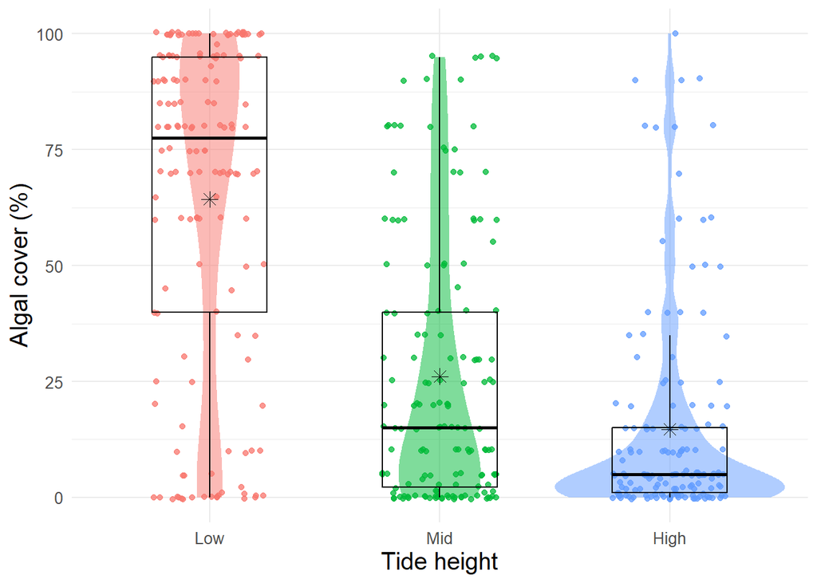

```r
ggplot(data = Data_Intertidal,
       mapping = aes(x = Quadrat,
                     y = Algae,
                     color = Quadrat,
                     fill = Quadrat)) +
  geom_violin(alpha = 0.5,
              width = 1.00,
              color = NA) + # NA for color so no border on violin plot
  geom_jitter(width = 0.25,
              alpha = 0.75) +
  geom_boxplot(color = "black",
               width = 0.50,
               fill = NA,
               outliers = FALSE) +
  stat_summary( # this section adds the white mean bar inside of the boxplot
    fun = mean,
    geom = "point",
    shape = 8,
    size = 3,
    color = "black",
    show.legend = FALSE
  ) +
  labs(x = "Tide height", # x-axis title
       y = "Algal cover (%)") + #y-axis title
  theme_minimal() +
  theme(legend.position = "none",
        axis.title.x = element_text(size = 15), # x-axis title size
        axis.title.y = element_text(size = 15), # y-axis title size
        axis.text.x = element_text(size = 10), # x-axis text size
        axis.text.y = element_text(size = 10), #y-axis text size
        panel.grid.major.y = element_line(), # Major y axis gridlines
        panel.grid.minor.y = element_line() # Minor y axis gridlines
  )
```

**5. Save plot**

```r
# Fixing my mistakes from last week where I forgot to save my output :)

ggsave(here("Week_09/Output/Week_09_Homework.png"),
       width = 7, height = 5) # reminder that this is in inches
```

### Instructions

1. Make a plot where at least one axis is a **factor in a meaningful order**.

   Done!
2. You may need to use string-cleaning skills (check out the **{janitor}** [package](https://sfirke.github.io/janitor/articles/janitor.html)) to tidy column names

   Done!
3. If you visualize by **tide height**, it must go Low → Mid → High on the plot

   Done!